## Example: State.x77 Data: matrix with 50 rows and 8 columns

- Population: population estimate as of July 1, 1975
- Income: per capita income (1974)
- Illiteracy: illiteracy (1970, percent of population)
- Life.Exp: life expectancy in years (1969–71)
- Murder: murder and non-negligent manslaughter rate per 100,000 population (1976)
- HS.Grad: percent high-school graduates (1970)
- Frost: mean number of days with minimum temperature below freezing (1931–1960) in capital or large city
- Area: land area in square miles

### Fit a linear regression model to predict Life Expectancy with all other 7 predictors.

```r
library(faraway)
# ?state.x77
statedata=data.frame(state.x77,row.names=state.abb,check.names=T)
g = lm(Life.Exp ~., data=statedata)
summary(g)
```

```
##
## Call:
## lm(formula = Life.Exp ~ ., data = statedata)
##
## Residuals:
##      Min       1Q   Median       3Q      Max
## -1.48895 -0.51232 -0.02747  0.57002  1.49447
##
## Coefficients:
##               Estimate Std. Error t value Pr(>|t|)
## (Intercept)  7.094e+01  1.748e+00  40.586  < 2e-16 ***
## Population   5.180e-05  2.919e-05   1.775   0.0832 .
## Income      -2.180e-05  2.444e-04  -0.089   0.9293
## Illiteracy   3.382e-02  3.663e-01   0.092   0.9269
## Murder      -3.011e-01  4.662e-02  -6.459 8.68e-08 ***
## HS.Grad      4.893e-02  2.332e-02   2.098   0.0420 *
## Frost       -5.735e-03  3.143e-03  -1.825   0.0752 .
## Area        -7.383e-08  1.668e-06  -0.044   0.9649
## ---
## Signif. codes:  0 '***' 0.001 '**' 0.01 '*' 0.05 '.' 0.1 ' ' 1
##
## Residual standard error: 0.7448 on 42 degrees of freedom
## Multiple R-squared:  0.7362, Adjusted R-squared:  0.6922
## F-statistic: 16.74 on 7 and 42 DF,  p-value: 2.534e-10
```

Check outliers

```r
n=dim(statedata)[1]
sort(abs(rstudent(g)), decreasing=TRUE)[1:5]
```

```
##       HI       ME       SC       AK       AR
## 2.735242 2.232206 1.615402 1.606163 1.562068
```

```r
qt(0.05/(n*2), 41)
```

```
## [1] -3.544184
```

Check high-influential points

```r
cook = cooks.distance(g)
max(cook)
```

```
## [1] 1.320804
```

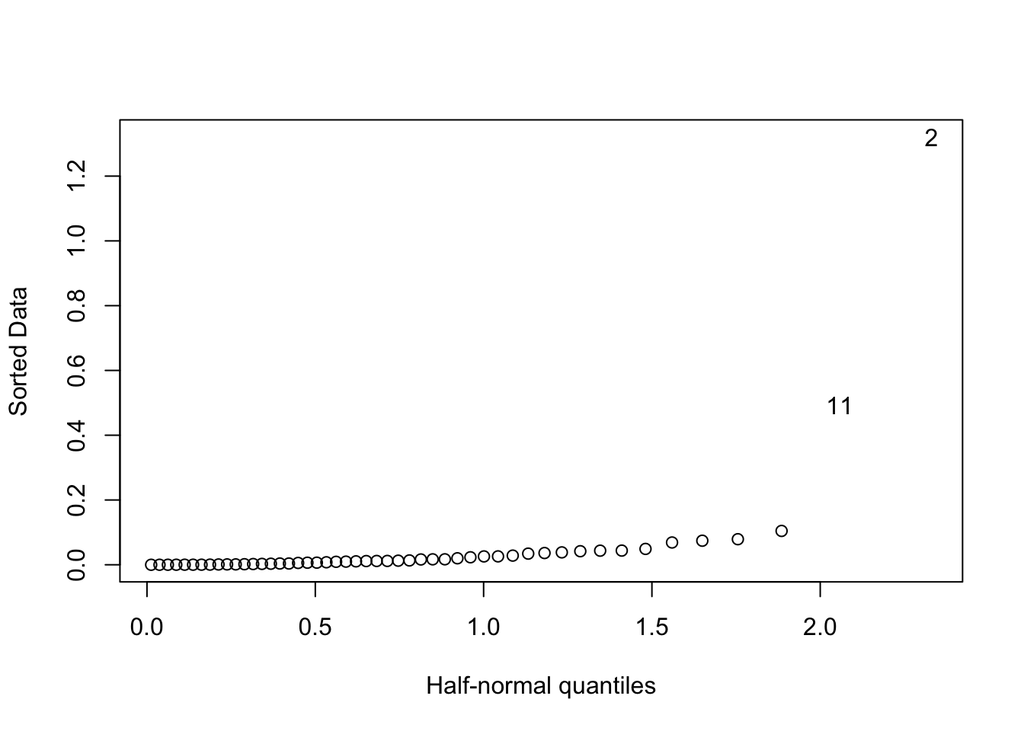

```r
#sort(cook)
halfnorm(cook)
```

Let’s first keep observation AK in our model, and then we’ll repeat the analysis without AK.

Variable selection with `leaps` package.

```r
library(leaps)
b=regsubsets(Life.Exp~., data = statedata)
rs = summary(b)
rs$which
```

```
##   (Intercept) Population Income Illiteracy Murder HS.Grad Frost  Area
## 1        TRUE      FALSE  FALSE      FALSE   TRUE   FALSE FALSE FALSE
## 2        TRUE      FALSE  FALSE      FALSE   TRUE    TRUE FALSE FALSE
## 3        TRUE      FALSE  FALSE      FALSE   TRUE    TRUE  TRUE FALSE
## 4        TRUE       TRUE  FALSE      FALSE   TRUE    TRUE  TRUE FALSE
## 5        TRUE       TRUE   TRUE      FALSE   TRUE    TRUE  TRUE FALSE
## 6        TRUE       TRUE   TRUE       TRUE   TRUE    TRUE  TRUE FALSE
## 7        TRUE       TRUE   TRUE       TRUE   TRUE    TRUE  TRUE  TRUE
```

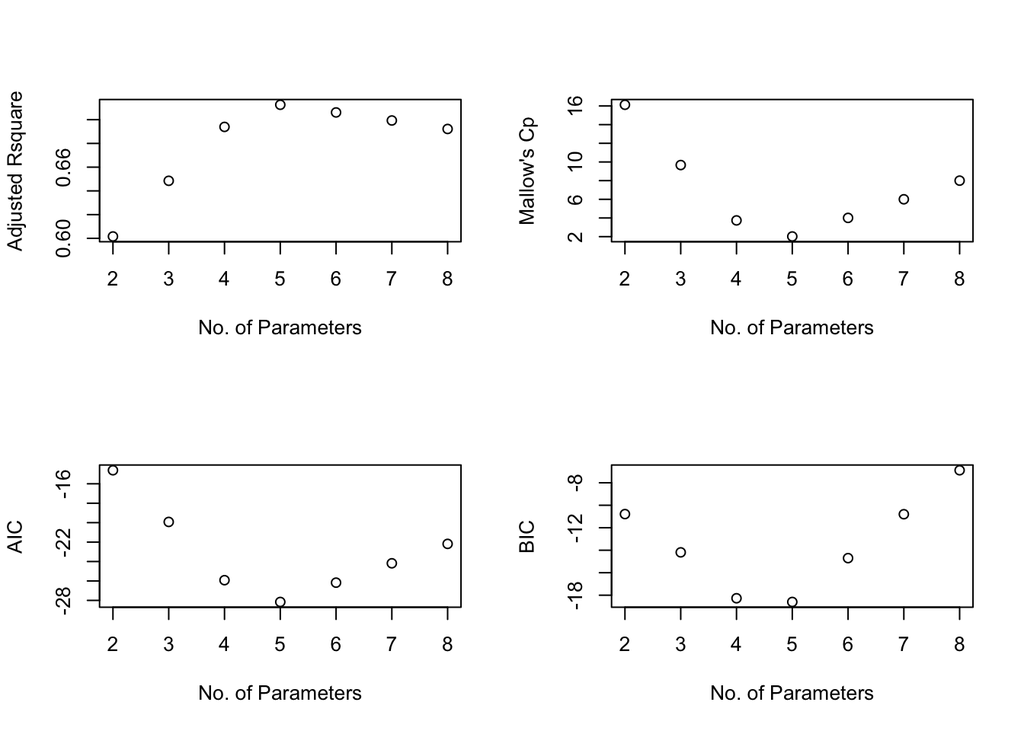

```r
n=dim(statedata)[1]; msize = 2:8;
par(mfrow=c(2,2))
plot(msize, rs$adjr2, xlab="No. of Parameters", ylab = "Adjusted Rsquare");
plot(msize, rs$cp, xlab="No. of Parameters", ylab = "Mallow's Cp");

Aic = n*log(rs$rss/n) + 2*msize;
Bic = n*log(rs$rss/n) + msize*log(n);
plot(msize, Aic, xlab="No. of Parameters", ylab = "AIC");
plot(msize, Bic, xlab="No. of Parameters", ylab = "BIC");
```

For this particular data set, AIC and BIC end up selecting the same model. Sometimes, the models selected by different criteria may be different.

```r
rs$which[which.min(Aic),]
```

```
## (Intercept)  Population      Income  Illiteracy      Murder     HS.Grad
##        TRUE        TRUE       FALSE       FALSE        TRUE        TRUE
##       Frost        Area
##        TRUE       FALSE
```

```r
select.var = colnames(rs$which)[rs$which[which.min(Aic),]]
select.var = select.var[-1]
myfit = lm(Life.Exp ~ . , data=statedata[, c(select.var, "Life.Exp")])
summary(myfit)
```

```
##
## Call:
## lm(formula = Life.Exp ~ ., data = statedata[, c(select.var, "Life.Exp")])
##
## Residuals:
##      Min       1Q   Median       3Q      Max
## -1.47095 -0.53464 -0.03701  0.57621  1.50683
##
## Coefficients:
##               Estimate Std. Error t value Pr(>|t|)
## (Intercept)  7.103e+01  9.529e-01  74.542  < 2e-16 ***
## Population   5.014e-05  2.512e-05   1.996  0.05201 .
## Murder      -3.001e-01  3.661e-02  -8.199 1.77e-10 ***
## HS.Grad      4.658e-02  1.483e-02   3.142  0.00297 **
## Frost       -5.943e-03  2.421e-03  -2.455  0.01802 *
## ---
## Signif. codes:  0 '***' 0.001 '**' 0.01 '*' 0.05 '.' 0.1 ' ' 1
##
## Residual standard error: 0.7197 on 45 degrees of freedom
## Multiple R-squared:  0.736,  Adjusted R-squared:  0.7126
## F-statistic: 31.37 on 4 and 45 DF,  p-value: 1.696e-12
```

`leaps` does not return AIC, but BIC. Its BIC differs from what we computed above, but the difference is a constant, so the two BIC formulae (mine and the one used by `leaps`) are essentially the same.

```r
names(rs)
```

```
## [1] "which"  "rsq"    "rss"    "adjr2"  "cp"     "bic"    "outmat" "obj"
```

```r
cbind(rs$bic, Bic,rs$bic-Bic )
```

```
##                      Bic
## [1,] -39.22051 -10.78522 -28.43529
## [2,] -42.62472 -14.18943 -28.43529
## [3,] -46.70678 -18.27149 -28.43529
## [4,] -47.03640 -18.60111 -28.43529
## [5,] -43.13738 -14.70209 -28.43529
## [6,] -39.23342 -10.79813 -28.43529
## [7,] -35.32373  -6.88844 -28.43529
```

Stepwise algorithm based on AIC and BIC

```r
step(g, direction="both")
```

```
## Start:  AIC=-22.18
## Life.Exp ~ Population + Income + Illiteracy + Murder + HS.Grad +
##     Frost + Area
##
##              Df Sum of Sq    RSS     AIC
## - Area        1    0.0011 23.298 -24.182
## - Income      1    0.0044 23.302 -24.175
## - Illiteracy  1    0.0047 23.302 -24.174
## <none>                    23.297 -22.185
## - Population  1    1.7472 25.044 -20.569
## - Frost       1    1.8466 25.144 -20.371
## - HS.Grad     1    2.4413 25.738 -19.202
## - Murder      1   23.1411 46.438  10.305
##
## Step:  AIC=-24.18
## Life.Exp ~ Population + Income + Illiteracy + Murder + HS.Grad +
##     Frost
##
##              Df Sum of Sq    RSS     AIC
## - Illiteracy  1    0.0038 23.302 -26.174
## - Income      1    0.0059 23.304 -26.170
## <none>                    23.298 -24.182
## - Population  1    1.7599 25.058 -22.541
## + Area        1    0.0011 23.297 -22.185
## - Frost       1    2.0488 25.347 -21.968
## - HS.Grad     1    2.9804 26.279 -20.163
## - Murder      1   26.2721 49.570  11.569
##
## Step:  AIC=-26.17
## Life.Exp ~ Population + Income + Murder + HS.Grad + Frost
##
##              Df Sum of Sq    RSS     AIC
## - Income      1     0.006 23.308 -28.161
## <none>                    23.302 -26.174
## - Population  1     1.887 25.189 -24.280
## + Illiteracy  1     0.004 23.298 -24.182
## + Area        1     0.000 23.302 -24.174
## - Frost       1     3.037 26.339 -22.048
## - HS.Grad     1     3.495 26.797 -21.187
## - Murder      1    34.739 58.041  17.456
##
## Step:  AIC=-28.16
## Life.Exp ~ Population + Murder + HS.Grad + Frost
##
##              Df Sum of Sq    RSS     AIC
## <none>                    23.308 -28.161
## + Income      1     0.006 23.302 -26.174
## + Illiteracy  1     0.004 23.304 -26.170
## + Area        1     0.001 23.307 -26.163
## - Population  1     2.064 25.372 -25.920
## - Frost       1     3.122 26.430 -23.877
## - HS.Grad     1     5.112 28.420 -20.246
## - Murder      1    34.816 58.124  15.528
```

```
##
## Call:
## lm(formula = Life.Exp ~ Population + Murder + HS.Grad + Frost,
##     data = statedata)
##
## Coefficients:
## (Intercept)   Population       Murder      HS.Grad        Frost
##   7.103e+01    5.014e-05   -3.001e-01    4.658e-02   -5.943e-03
```

```r
step(g, direction="both", k=log(n))
```

```
## Start:  AIC=-6.89
## Life.Exp ~ Population + Income + Illiteracy + Murder + HS.Grad +
##     Frost + Area
##
##              Df Sum of Sq    RSS      AIC
## - Area        1    0.0011 23.298 -10.7981
## - Income      1    0.0044 23.302 -10.7910
## - Illiteracy  1    0.0047 23.302 -10.7903
## - Population  1    1.7472 25.044  -7.1846
## - Frost       1    1.8466 25.144  -6.9866
## <none>                    23.297  -6.8884
## - HS.Grad     1    2.4413 25.738  -5.8178
## - Murder      1   23.1411 46.438  23.6891
##
## Step:  AIC=-10.8
## Life.Exp ~ Population + Income + Illiteracy + Murder + HS.Grad +
##     Frost
##
##              Df Sum of Sq    RSS      AIC
## - Illiteracy  1    0.0038 23.302 -14.7021
## - Income      1    0.0059 23.304 -14.6975
## - Population  1    1.7599 25.058 -11.0691
## <none>                    23.298 -10.7981
## - Frost       1    2.0488 25.347 -10.4960
## - HS.Grad     1    2.9804 26.279  -8.6912
## + Area        1    0.0011 23.297  -6.8884
## - Murder      1   26.2721 49.570  23.0406
##
## Step:  AIC=-14.7
## Life.Exp ~ Population + Income + Murder + HS.Grad + Frost
##
##              Df Sum of Sq    RSS     AIC
## - Income      1     0.006 23.308 -18.601
## - Population  1     1.887 25.189 -14.720
## <none>                    23.302 -14.702
## - Frost       1     3.037 26.339 -12.488
## - HS.Grad     1     3.495 26.797 -11.627
## + Illiteracy  1     0.004 23.298 -10.798
## + Area        1     0.000 23.302 -10.790
## - Murder      1    34.739 58.041  27.017
##
## Step:  AIC=-18.6
## Life.Exp ~ Population + Murder + HS.Grad + Frost
##
##              Df Sum of Sq    RSS     AIC
## <none>                    23.308 -18.601
## - Population  1     2.064 25.372 -18.271
## - Frost       1     3.122 26.430 -16.228
## + Income      1     0.006 23.302 -14.702
## + Illiteracy  1     0.004 23.304 -14.697
## + Area        1     0.001 23.307 -14.691
## - HS.Grad     1     5.112 28.420 -12.598
## - Murder      1    34.816 58.124  23.176
```

```
##
## Call:
## lm(formula = Life.Exp ~ Population + Murder + HS.Grad + Frost,
##     data = statedata)
##
## Coefficients:
## (Intercept)   Population       Murder      HS.Grad        Frost
##   7.103e+01    5.014e-05   -3.001e-01    4.658e-02   -5.943e-03
```

Repeat the above variable selection algorithm without the observation AK.

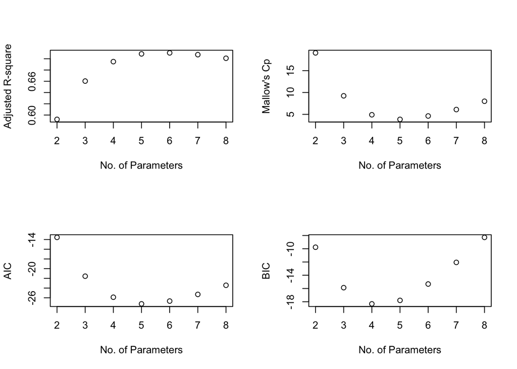

```r
b = regsubsets(Life.Exp ~., data=statedata[-2, ])
rs = summary(b)
n=49; msize = 2:8;
par(mfrow=c(2,2))
plot(msize, rs$adjr2, xlab="No. of Parameters", ylab = "Adjusted R-square");
plot(msize, rs$cp, xlab="No. of Parameters", ylab = "Mallow's Cp");
Aic = n*log(rs$rss/n) + 2*msize;
Bic = n*log(rs$rss/n) + msize*log(n);
plot(msize, Aic, xlab="No. of Parameters", ylab = "AIC");
plot(msize, Bic, xlab="No. of Parameters", ylab = "BIC")
```

**Remark on R functions AIC and BIC:** $\textbf{R}$ has built in functions AIC and BIC for extracting these metrics from a model objects. In the penalty these functions use $p+1$ instead of $p$ due to estimating the residual variance $\sigma^2$. This difference does not affect the minimization because it is simply another additive constant in the criterion.